# Starten met git

Thierry Onkelinx

03-02-2015

# Starten met git

- Ga na of git geïnstalleerd is. Volgens de BMK instructies moet dat in `c:\R\git`
- Ga na op git geconfigureerd is in RStudio.
  - Ga naar `Tools` -> `Global options`
  - Open het tabblad `Git/SVN`
  - Zorg dat hier verwijzing naar de git executable correct staat
- Typografie
  - `RStudio namen, knoppen, opties, items in menubalken, ...`
  - `shell commando's of bestandsnamen`
  - *git gerelateerde termen*
  - **namen van git branches**

# Lokale projecten

Een lokaal project staat enkel op jouw computer. Je hebt dus geen servers of andere computers nodig om versiebeheer te gebruiken! Een eigen lokaal project is prima om te leren werken met git. Je kan alle doen, behalve de stappen die verband houden met het synchroniseren tussen computers / servers.

## Eenvoudig nieuw project

### Een project starten

- Kies in RStudio voor `File` -> `New project` -> `Empty project`.
  - Vul de gewenste naam van het project in en de gewenste directory waarin het project moet komen.
  - Vink `create a git repository` aan.
  - Klik `Create repository`
  - Het nieuwe project wordt nu geopent
- RStudio voegt een tabblad `Git` toe aan de editor. In dit tabblad doe je alle bewerkingen gerelateerd aan het versiebeheer
  - Je vindt er steeds een overzicht van de status van alle bestanden m.b.t. versiebeheer
  - Op dit moment zal je er twee bestanden vinden: `.gitignore` en `jouw_project.Rproj`
  - In de kolom `Status` zie je twee keer een vraagteken in een geel veld. Dat wijst op een *untracked* bestand. Dergelijke bestanden worden genegeerd door het versiebeheer. Merk op dat geen enkel bestand automatisch wordt opgenomen in het versiebeheer.
- Klik rechts op `jouw_project.Rproj` en kies `ignore`. Nu open een beknopte editor met de inhoud van `.gitignore`. Hier geef je de namen van de bestanden of mappen weer die git standaard moet genegeren. Een *ignored* bestand wordt, net zoals een *untracked* bestand niet opgenomen in het versiebeheer. Het verschil tussen beide is dat *ignored* bestanden niet zichtbaar zullen zijn in het `Git` tabblad.
  - Wijzig `jouw_project.Rproj` in `*.Proj` en klik op `Save` Vanaf nu zullen alle bestanden die eindigen met `.Proj` de *ignored* status krijgen. Merk op dat `jouw_project.Rproj` nu uit het `Git` tabblad verdwenen is.
  - Regel uit `.gitignore` wissen = *ignore* ongedaan maken.
- Wanneer *ignore* gebruiken
  - Vuistregel: telkens je het bestand in kwestie makkelijk kan aanmaken met de gegevens in de repository
  - Bijvoorbeeld: figuren, pdf, md en tex bestanden die ontstaan na het compileren van een RMarkdown (.Rmd) bestand
  - RStudio vult standaard `.Rproj.user`, `.Rhistory` en `.RData`. `.Rproj.user` is de map met alle tijdelijke bestanden van het project. `.Rhistory` bevat een lijst van alle commando’s die je uitvoert. `.RData` zijn de objecten in de workspace. Deze bestanden zijn niet relevant om onder versiebeheer te plaatsen.
  - Best ook `*.Rproj`. Je krijgt anders problemen wanneer het project vanop meerdere computers gebruikt wordt.
- `.gitignore` plaats je best onder versiebeheer. Op die manier zal iedereen dezelfde bestanden *ignoren*.
- Nu maken we een eerste *commit*. Een *commit* is een snapshot van de versie van de bestanden op dat ogenblik. De eerste stap bij het maken van een *commit* is bepalen welke gewijzigde bestanden relevant zijn om op te nemen in de *commit*. Merk op dat het niet noodzakelijk is om alle gewijzigde bestanden op te nemen in een *commit*.
  - Je moet eerst de gewenste bestanden *stagen* = klaarzetten om op te nemen in de snapshot. Dat doe je door `Staged` aan te vinken voor de naam van het bestand. Doe dit met `.gitignore`. Door te *stagen* verandert de status van *untracked* bestanden naar *added*, aangegeven door een “A” op een turkoois veld in de linkerhelft van de `Status` kolom.
  - Door `Staged` terug uit te vinken herstel je de status van het bestand naar de vorige status.
- Eens alle gewenste bestanden *gestaged* zijn, kan je *committen* door op de knop *commit* te klikken.
  - Nu opent een venster met heel wat informatie over de wijzigingen.
  - Je krijgt een venster met de betrokken bestanden. Hier kan je nog wijzigingen aanbrengen zoals in het `Git tabblad` (*stage*, *unstage*, *ignore*)
  - Onderaan krijg je de *diff* te zien van het bestand. Groene regels zijn toegevoegd, rode regels zijn gewist, witte regels zijn ongewijzigd.
    - In de *diff* worden standaard enkel de 5 ongewijzigde regels voor en naar een wijziging getoond. Ook een enkel wijziging aan het einde van een lang bestand zie je op die manier dadelijk.
    - De hoeveelheid context kan je aanpassen via de dropdrop `Context` (5, 10, 25, 50 of alle lijnen)
    - De *Diff* is deze van het geselecteerd bestand. Klik op de bestandsnaam om een ander bestand te selecteren.
    - Een *Diff* werkt enkel bij bestanden met platte tekst. Niet met binaire bestanden (pdf, docx, jpg, Rdata, …)
  - Naast de lijst met bestanden staat een tekstveld `Commit message`. Hierin moet je een tekst schrijven. Deze tekst beschrijft de wijzigingen in deze *commit*.
    - Een goede *commit message* is cruciaal. Het is de enige manier om later te weten waarom je een bepaalde wijzigingen aanbracht.
  - `Amend previous commit` kan je gebruiken indien je een bestand vergeten te *stagen* en je wilt het alsnog toevoegen aan de vorige *commit*.
  - Als je klaar bent (= alle gewenste bestanden *gestaged* en een goede *commit message* geschreven), dan kan je op `Commit` klikken. Je krijgt dan een nieuw venster met een beknopt overzicht van de wijzigingen. Klik op `Close` om het af te sluiten. Je kan vervolgens het `Commit` venster sluiten.
  - De *gestagede* bestanden zijn nu verdwenen uit het `Git` tabblad.
- Maak bovenstaand RStudio project
- Plak onderstaande code in `script1.R`

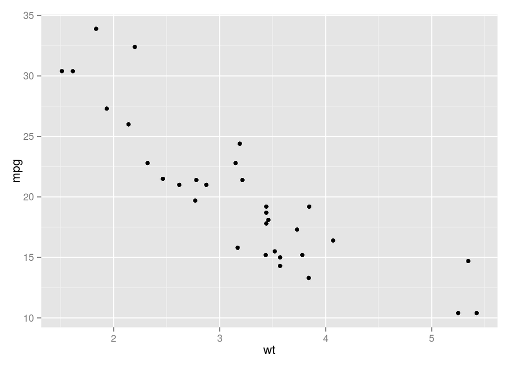

```r
library(ggplot2)
ggplot(mtcars, aes(wt, mpg)) + geom_point()
```

- Plak onderstaande code in `script2.R`

```r
ctl <- c(4.17,5.58,5.18,6.11,4.50,4.61,5.17,4.53,5.33,5.14)
trt <- c(4.81,4.17,4.41,3.59,5.87,3.83,6.03,4.89,4.32,4.69)
group <- gl(2, 10, 20, labels = c("Ctl","Trt"))
weight <- c(ctl, trt)
lm.D9 <- lm(weight ~ group)

anova(lm.D9)
```

```
## Analysis of Variance Table
##
## Response: weight
##           Df Sum Sq Mean Sq F value Pr(>F)
## group      1 0.6882 0.68820  1.4191  0.249
## Residuals 18 8.7292 0.48496
```

```r
summary(lm.D9)
```

```
##
## Call:
## lm(formula = weight ~ group)
##
## Residuals:
##     Min      1Q  Median      3Q     Max
## -1.0710 -0.4938  0.0685  0.2462  1.3690
##
## Coefficients:
##             Estimate Std. Error t value Pr(>|t|)
## (Intercept)   5.0320     0.2202  22.850 9.55e-15 ***
## groupTrt     -0.3710     0.3114  -1.191    0.249
## ---
## Signif. codes:  0 '***' 0.001 '**' 0.01 '*' 0.05 '.' 0.1 ' ' 1
##
## Residual standard error: 0.6964 on 18 degrees of freedom
## Multiple R-squared:  0.07308,    Adjusted R-squared:  0.02158
## F-statistic: 1.419 on 1 and 18 DF,  p-value: 0.249
```

- *Stage* `script1.R` en *commit*.
- *Stage* `script2.R` en *commit* met de `Amend previous commit` optie aangevinkt.

### Bestaande bestanden wijzigen

- Van zodra een bestand na een commit gewijzigd wordt, zal git het terug automatisch in het `Git` tabblad tonen.
  - De status van dergelijke bestanden is *unstaged modified* aangegeven door een “M” op een blauw veld in de rechter kolom van `Status`.
- Wanneer we nu een snapshot willen maken van de de huidige versie, moeten we de gewijzigde bestanden opnieuw *stagen*.
  - Behalve het vinkje in `Staged` zal ook de “M” in `Status` verplaatsen naar de linker kolom (*staged modified*).
  - Het bestand is nu gewijzigd én de wijzigingen zijn klaar voor een *commit*. OOk nu worden de wijzigingen past toegevoegd aan het versiebeheer na een *commit*!
- Wijzig `script1.R` naar

```r
library(ggplot2)
p <- ggplot(mtcars, aes(wt, mpg)) + geom_point()
ggsave(p, file = "script1.jpg")
```

- Voer `script1.R` uit
- *Stage* `script1.R`
- Wijzig `script1.R` naar

```r
library(ggplot2)
p <- ggplot(mtcars, aes(wt, mpg)) + geom_point()
ggsave(p, file = "script1.png")
```

- Merk dat we `script1.R` gewijzigd hebben, vervolgens *gestaged* en dan weer gewijzigd terwijl we nog geen *commit* gedaan hebben.
  - Het vinkje in `Staged` wordt nu een vierkant en `Status` toont zowel links als rechts “M” (*staged and unstaged modified*).
  - Deze meer complexe situatie leggen we later in detail uit.
  - Voorlopig passen we dit aan door `script1.R` opnieuw te *stagen*. Nu krijgen we terug een vinkje en de linker “M” (*staged modified*)
- *Ignore* `script1.jpg`
- *Stage* `script1.png`
- *Stage* `.gitignore`
- Kijk naar de *Diff* van `.gitignore`, `script1.jpg` en `script1.R`
- *Commit* de wijzigingen.

### Bestanden wissen en terug zetten naar de laatste commit

- Voer `script1.R` opnieuw uit. Merk op dat er nu niets gebeurd in het `Git` tabblad. Hoewel `script1.png` gewijzigd is, is de inhoud dezelfde gebleven. Een nieuwe versie opslaan is daarom overbodig.
- Wijzig `script1.R` naar onderstaande code, sla het op en voer opnieuw uit

```r
library(ggplot2)
p <- ggplot(mtcars, aes(wt, mpg)) + geom_jitter()
ggsave(p, file = "script1.png")
```

- Zowel `script1.R` als `script1.png` zijn nu *unstaged modified*
- Stel dat we `script1.png` niet langer onder versiebeheer wensen.
  - Wis `script1.R` van de harde schijf
  - `script1.R` blijft staan in het `Git` tabblad. De `Status` is nu *unstaged deleted*, aangezien door “D” in een rood veld in de rechter kolom van `Status`.
  - Oeps, we wensten `script1.png` te wissen in plaats van `script1.R`
  - Rechts klik op `script1.R` in het `Git` tabblad en klik op `Revert`. Je krijgt nu een waarschuwing dat eventuele wijzingen verloren gaan. Klik op `Yes`. Git zal nu de versie van `script1.R` uit de laatste commit terug plaatsen. Alle wijzigingen sinds de laatste commit zijn verloren.
  - Wis `script1.png` van de harde schijf.
  - *Stage* en *commit* `script1.png`
- Voer `script1.R` opnieuw uit. `script1.png` wordt opnieuw aangemaakt en is nu terug *untracked*.

## Een bestaand project onder enkel lokaal onder versiebeheer plaatsen

- Open het project in RStudio
- Ga in het menu naar `Tools` -> `Project options`
- Kies het tabblad `Git/SVN`
- Kies `Git` bij `Version control system`
- Bevestig jouw keuze
- Herstart RStudio
- Van nu kan je alle bewerkingen uit voorgaande (en komende) secties toepassen.

## *Branches*

- In een eenvoudige git repository staan alle *commits* achter elkaar in een lange rij.
- git laat toe om op een eenvoudige manier met meerdere *branches* te werken. Een *branch* is een vertakking vanaf een bepaald *commit*. Beide *branches* hebben tot de *commit* waar ze vertakken dezelfde voorgeschiedenis. Na deze *commit* kunnen ze elk een andere weg op gaan.
  - Ze gaan elk aan een eigen ‘snelheid’ verder gaan.
  - Ze zullen een andere inhoud hebben.

### Eenvoudig *branching* model

- Standaard is er enkel een **master** *branch*.
- Een vaak gebruikte tweede *branch* is **develop**.
- In dergelijke configuratie bevat **master** de laatste ‘officiële’ versie.
  - een rapport onder de vorm dat het naar de stuugroep gaat
  - documenten van een les zoals het naar de cursisten gaat
  - een bepaalde versie van een R package
- **develop** bevat dan de versie waar je effectief in werkt.
  - Wanneer de versie in **develop** voldoende uitgekristaliseerd is zullen we die terug invoegen in **master**.
- git laat toe om vlot om te schakelen tussen *branches*.
  - Bij het overschakelen tussen *branches* worden alle bestanden van de huidige *branch* vervangen door de bestanden van de (laatste *commit* van de) nieuwe *branch*.
  - *untracked* en *ignored* bestanden blijven behouden.
- je kan met de GUI in het `Git` tabblad enkel wisselen tussen *branches*. Andere bewerking moet je vanaf de command line doen. Klik op het tandwiel icoontje in het `Git` tabblad en kies `Shell...`. Dan krijg je een command line waar je `git` commando’s kan ingeven. Alle `git` commando’s beginen met `git`.
- We maken een **develop** *branch* vanaf de huidige *commit* met `git branch develop`
- Vervolgens maken we **develop** actief met `git checkout develop`
- Met `exit` sluiten we de shell terug.
- Zorg dat de **develop** *branch* actief is
  - De actieve *branch* staat rechtsboven aan het `Git` tabblad
- Voeg onderstaande code toe onderaan `script2.R`

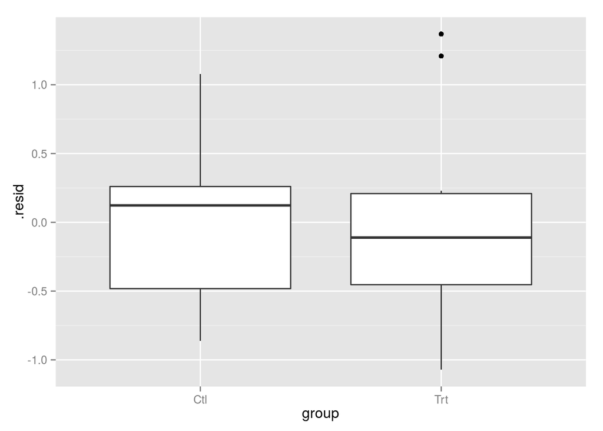

```r
library(ggplot2)
ggplot(lm.D9, aes(x = group, y = .resid)) + geom_boxplot()
```

- (*Stage* en ) *commit* de wijzigingen aan `script2.R`
- *checkout* **master**
  - ofwel: in de git shell `git checkout master`
  - ofwel: in het `Git` tabblad klikken op de naam van het huidige *branch*. Kies vervolgens de **master** *brnach* uit de dropdown lijst
  - Merk op dat de inhoud van `script2.R` terug de vorige versie bevat.
- Ga terug naar de **develop** *branch*
- Voeg in `script2.R` de onderstaande regel toe

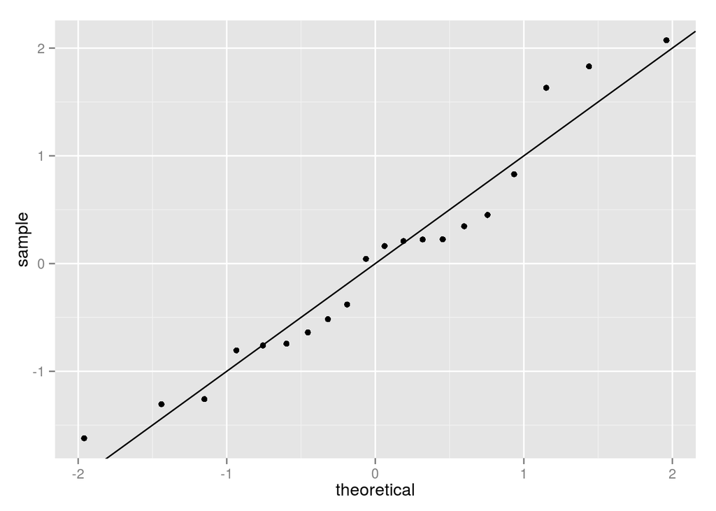

```r
ggplot(lm.D9, aes(sample = .stdresid)) + stat_qq() + geom_abline()
```

- *Commit* deze wijzigingen
- Nu gaan we de wijzigingen in **develop** als een blok toepassen op **master**
  - Ga naar de git shell
  - *Checkout* de *branch* naar waar je wenst te *mergen*
    - `git checkout master`
  - *Merge* **develop** naar **master** zonder *fast-forward*
    - `git merge --no-ff develop`
  - Je krijgt een editor venster waarin je een aangepaste *commit message* schrijft. Hier beschijft je beknopt de belangrijkste wijzigingen sinds de vorige merge tussen **master** en **develop**
    - Daarom kijk je best EERST naar de *history* van de **develop** *branch*
- Klik op het uurwerk icoon in het `Git` tabblad. Dit geeft een overzicht van de *history* van de *repository*.
  - Het bovenste deel toont alle *commits*
    - Je ziet enkel de *commit message*. Vandaar dat het belangrijk is dat de *commit message* reeds een ruw idee geeft van wat er aangepast is.
    - Tip: Vaak *committen* heeft als voordeel dat een beknoptere *commit messages* volstaat op de wijzigingen te beschrijven.
    - Bij elke *commit* zie je ook de auteur, date en SHA. Deze laatste is de id van de *commit*
  - Het verband tussen de *commits* wordt grafisch voorgesteld.
    - De cirkels zijn de *commits*
    - De lijnen geven het verband tussen de *commits*
    - De oudste *commits* staan onderaan
    - *Commits* waaruit twee (of meer) lijnen naar boven vertrekken geven aan dat daar twee *branches* splitsen.
    - *Commits* waarin twee lijnen samenkomen geven aan dat de twee *branches* daar weer *gemerged* werden.
    - De lijnen en nodes van elke *branch*wordt met een andere kleur weergegeven.
  - Voor sommige *commit messages* staat de naam van een *branch*. Hiermee wordt de laatste *commit* van elke *branch* aangegeven. *HEAD* is geen *branch* maar geeft aan welke *commit* op dit ogenblik actief is. Dit valt in principe samen met de actieve *branch*.
  - Het onderste deel van het scherm geeft aan welke bestanden gewijzigd zijn en wat de *diffs* weer van de geselecteerde *commit* ten opzichte van zijn voorgaande *commit* (de *parent commit*).

### Meer uitgebreid *branching* model

Het eenvoudige *branching* model zorgt er voor dat de **master** behoorlijk clean blijft. **develop** bevat echter alle sequentele wijzigingen. Dat is prima voor een beperkt project waar slechts een persoon aan werkt. Voor complexere projecten waar je met meerdere mensen aan werkt of dat uit verschillende facetten bestaat, is dat minder praktisch. In dergelijke situaties is het handig om zogenaamde **feature** *branches* te maken.

#### Project met permanent scheidbare features

Voorbeeld: een project van een lessenreeks die uit verschillende lessen bestaat. Elke les heeft zijn eigen broncode en datasets.

Praktisch voorbeeld:

- Maak een nieuw project “Lessenreeks” met git versie controle
- *Ignore* `*.Rproj`, *stage* `.gitignore` en *commit*
- Maak een **develop** *branch* en doe een *checkout* van **develop**
- Maak een **les1** *branch* en een **les2** *branch*
- *Checkout* **les1**
- Maak een bestand, *stage* en *commit* het
- Maak een nog bestand, *stage* en *commit* het
- *Checkout* **les2**
- Maak een bestand, *stage* en *commit* het
- *Checkout* **les1**
- Pas een bestand aan, *stage* en *commit* het
- Op dit ogenblik hebben we vier *branches*: **master**, **develop**, **les1** en **les2**. **master** en **develop** staan nog aan het beginpunt, **les1** en **les2** zijn onafhankelijk van elkaar gegroeid.
- Veronderstel dat de draft van **les1** nu klaar is. Dat is een goed moment om **les1** aan **develop** toe te voegen.
  - *Checkout* **develop**
  - *Merge* **les1** naar **develop** met `git merge --no-ff les1`
- Vervolgens werken we verder aan **les2**
  - Voor de eenvoud zullen we voor zorgen dat de bestandsnamen tussen **les1** en **les2** verschillen. De eenvoudigste manier om dit te garanderen is elke les een andere subdirectory te plaatsen.
  - *Checkout* **les2**
  - Pas een bestand aan, *stage* en *commit* het
- De draft van **les2** is nu eveneens klaar en we kunnen **les2** toevoegen aan **develop**
  - *Checkout* **develop**
  - *Merge* **les2** naar **develop** met `git merge --no-ff les2`
- We krijgen feedback. **les2** is in orde, **les1** vergt een aantal aanpassingen
  - *Checkout* **les1**
  - Pas een bestand aan, *stage* en *commit* het
  - Stuur de aanpassingen terug naar **develop**
    - *Checkout* **develop**
    - *Merge* **les1** naar **develop** met `git merge --no-ff les1`
- De lessen zijn nu klaar voor de studenten. Dus sturen we de wijzigingen van **develop** naar **master**
  - *Checkout* **master**
  - *Merge* **develop** naar **master** met `git merge --no-ff develop`
- Tijdens het geven van de les botsen we op een onduidelijkheid in **les2**. We plaatsen een reminder in de code.
  - *Checkout* **les2**
  - Pas een bestand aan, *stage* en *commit* het
- Kijk nu naar de *history* van de *repository* (klik op het uurwerk icoon in het `Git` tabblad)
  - Standaard krijgen we enkel de *commits* van de actieve *branch* te zien. In dit geval **les2**.
  - De *history* van **les2** is zeer clean. Ze bevat enkel *commits* die betrekking hebben op **les2**.
  - Om de *history* van een andere *branch* te zien, moet je op de dropbox lijst rechts van de `history` knop klikken. Doe dit en selecteer **les1**.
    - De *history* van **les1** is even clean als deze van **les2**. Uiteraard bevat ze allemaal andere *commits*. Enkel de allereerste *commit* waarmee we de *repository* gestart hebben is gemeenschappelijk (tussen alle *branches*).
  - Kijk nu naar de *history* van **develop**.
    - Deze *history* is complexer omdat we op een aantal momenten **les1** en **les2** toegevoegd hebben.
    - Niet tegenstaande de complexe structuur kunnen we vlot terugvinden wanneer **develop** aangepast was en welke *branch* toegevoegd werd.
    - Het aantal *commits* in **develop** blijft beperkt omdat elke *commit* van **develop** meerdere *commits* van **les1** of **les2** kan bevatten.
  - De *history* van **master** lijkt nog een tikje complexer. Tot je enkel kijkt naar welke *commits* in **master** zitten. Het zijn er weinig én ze komen enkel van **develop**. Bovendien bundelen ze meerdere *commits* van **develop**.
  - Kijk tenslotte naar de *history* van **all branches**.
    - Nu zie je duidelijk dat **les2** 1 *commit* voorloopt op **master** en **develop**.
    - **les2** is tevens duidelijk gescheiden van **les1** sinds de eerste *commit*.

Hoewel dit *branching model* complexer is, heeft het als grote voordeel dat de verschillende onderdelen (lessen in bovenstaand voorbeeld) duidelijk gescheiden blijven. Bovendien kunnen ze aan een verschillende snelheid verder uitgewerkt worden.

#### Project met onderling verweven features

In veel gevallen zal een project uit verschillende features bestaat die van elkaar afhankelijk zijn. In dat geval is het bovenstaande *branching model* niet meer mogelijk en moeten we het aanpassen. In dergelijk geval zullen we een nieuwe *branch* maken als we aan een nieuw feature beginnen. Eens het feature afgewerkt is, *merge* we het terug in **develop**. Op dat ogenblik hebben we de **feature** *branch* niet meer nodig en kunnen we die wissen.

Laat ons het voorbeeld nemen van een R package met drie features A, B en C. We werken eerst A uit, nadien B en C parallel. Zowel in B als C zullen we een aanpassing doen van eenzelfde element uit A.

Praktisch voorbeeld:

- Maak een nieuw project “dummypackage” met git versie controle
  - *Ignore* `*.Rproj`, *stage* `.gitignore` en *commit*
  - Maak een **develop** *branch* en doe een *checkout* van **develop**
- We werken eerst aan het inlezen van de gegevens
  - Maak een **featureA** *branch*
  - *Checkout* **featureA**
  - Zet onderstaande code een bestand `readData.R`, *stage* en *commit* het

    ```r
    readData <- function(n = 10){
      rnorm(n)
    }
    ```

  - Zet onderstaande code een bestand `featureA.R`, *stage* en *commit* het

    ```r
    featureA <- function(n = 20){
      mean(readData(n))
    }
    ```

- **featureA** is nu klaar. We *merge* het terug in **develop**
  - *checkout* **develop**
  - `git merge --no-ff featureA`
  - we wissen **featureA** met `git branch -d featureA`
  - Kijk nu naar de *history*. Er is geen *branch* meer met de naam **featureA** maar het blijft zichtbaar als een ‘zijsprong’ van **develop**
- We maken twee nieuwe *branches* **featureB** en **featureC** vanaf **develop**
- Eerste passen we **featureB** aan
  - *checkout* **featureB**
  - Pas `readData.R` aan zoals hieronder en *stage*

    ```r
    readData <- function(n = 10, sd = 1){
      rnorm(n, sd = sd)
    }
    ```

  - Pas `featureA.R` aan zoals hieronder en *stage*

    ```r
    featureA <- function(n = 20){
      mean(readData(n = n, sd = 1))
    }
    ```

  - *Commit* de wijzigingen
  - Zet onderstaande code een bestand `featureB.R`, *stage* en *commit* het

    ```r
    featureB <- function(n = 20, sd = 5){
      max(readData(n = n, sd = sd))
    }
    ```

- We werken we eerst **featureC** uit
  - *checkout* **featureC**
  - Pas `readData.R` aan zoals hieronder en *stage*

    ```r
    readData <- function(n = 10, mean = 0){
      rnorm(n = n, mean = mean)
    }
    ```

  - Pas `featureA.R` aan zoals hieronder en *stage*

    ```r
    featureA <- function(n = 20){
      mean(readData(n = n, mean = 0))
    }
    ```

  - *Commit* de wijzigingen
  - Zet onderstaande code een bestand `featureC.R`, *stage* en *commit* het

    ```r
    featureC <- function(n = 20, mean = 10){
      min(readData(n = n, mean = mean))
    }
    ```

- Nu gaan we **featureB** en **featureC** *mergen* in **develop**
- Eerst **featureB**
  - *Checkout* **develop**
  - `git merge --no-ff featureB`
  - `git branch -d featureB`
  - Kijk naar de *history*. Je kan zowel **featureA** als **featureB** nog onderscheiden, hoewel ze niet meer als *branch* beschikbaar zijn.
- Vervolgens **featureC**
  - Dit zal een *merge conflict* opleveren. Immers `readData.R` en `featureA.R` zijn zowel in **featureB** als **featureC** gewijzigd.
  - We proberen eerst de naïeve manier.
  - `git merge --no-ff featureC` geeft een foutmelding: “Automatic merge failed; fix conflicts and then commit the result.”
  - De wijzigingen die geen probleem opleverden zijn reeds uitgevoerd en *gestaged*.
  - De bestanden met conflicteren wijzigingen (wijzigingen in dezelfde regel!) hebben de `status` *unmerged*. Dit wordt aangegeven voor een “U” op een oranje veld.
  - `featureA.R` ziet er nu als volgt uit:

    ```r
    featureA <- function(n = 20){
    <<<<<<< HEAD
      mean(readData(n = n, sd = 1))
    =======
      mean(readData(n = n, mean = 0))
    >>>>>>> featureC
    }
    ```

  - Op de plaats van het conflict zie je dat beide versies worden weergegeven. Eerst die van de *HEAD* (*HEAD* = de huidige *checkout*). Dan de versie van de *branch* die we probeerden te mergen.
  - *Waarschuwing*: als we dit nu zouden *stagen* dan zal `git` de *merge conflicten* overnemen as is.
  - We moeten dus manueel de conflicten oplossen in de code. Vervolgens kunnen we *stagen*, *committen* en **featureC** wissen.
  - Negeren even de wijzigen van de huidige onafgewerkte *merge* met `git reset --hard`. Dit command zet *alle* wijzigingen terug naar de toestand van de laatste *commit*. `featureC.R` zat nog niet in **develop** en wordt daarom *untracked*.
- Veiligere manier om met *merge conflicten* om te gaan:
  1. *Merge* de wijzigingen van **develop** in **featureC**
  2. Los de *merge conflicten* op in **featureC** (in plaats van in **develop**)
  3. *Merge* de wijzigingen van **featureC** in **develop**. Dit geeft geen problemen omdat we de *merge conflicten* reeds opgelost hebben in **featureC**.
- Werkwijze
  - *Checkout* **featureC**
    - Dit kan nu een foutmelding geven omdat `featureC.R` als *untracked* bestaat én als *tracked* in **featureC.R**. Oplossingen: de *untracked* `featureC.R` wissen, hernoemen of *stagen* en *commiten*
    - We kiezen in dit geval voor wissen omdat het een restant is van de mislukte *merge*.
  - `git merge --no-ff develop`
  - Pas `readData.R` aan naar

    ```r
    readData <- function(n = 10, mean = 0, sd = 1){
      rnorm(n = n, mean = mean, sd = sd)
    }
    ```

  - Pas `featureA.R` aan naar

    ```r
    featureA <- function(n = 20){
      mean(readData(n = n, mean = 0, sd = 1))
    }
    ```

  - Hoewel `featureB.R` geeft *merge conflict* geeft, wordt het wel beïnvloed door de wijzigingen in `readData.R`. Pas `featureB.R` aan naar

    ```r
    featureB <- function(n = 20, sd = 5){
      max(readData(n = n, mean = 1, sd = sd))
    }
    ```

  - Idem voor `featureC.R`. Pas `featureC.R` aan naar

    ```r
    featureC <- function(n = 20, mean = 10){
      min(readData(n = n, mean = mean, sd = 0))
    }
    ```

  - *Stage* en *commit* alle wijzigingen
  - *Checkout* **develop**
  - `git merge --no-ff featureC`
  - `git branch -d featureC`

# Projecten op de Stash server

Via ACD heeft het INBO een Stash server ter beschikking. Je vindt deze server via https://git.milieuinfo.be. Inloggen doe je met behulp van je JIRA gebruikersnaam en wachtwoord. De toegang is niet automatisch. Je moet ze aanvragen via IDC (Kevin Azijn).

Persoonlijke *repositories* kan je vrij en onbeperkt zelf aanmaken. Meer generieke projecten dienen door IDC (Kevin Azijn) aangemaakt te worden.

## Een nieuw project op de Stash server plaatsen

Dit is de werkwijze die je best volgt als je een nieuw project wilt starten en er dadelijk ook een kopie van op Stash wenst. Dat is handig als je de optie wilt hebben om de inhoud vlot te delen met anderen. Dit is overigens geen verplichting!

- Maak de *repository* op Stash
  - Login op https://git.milieuinfo.be
  - Rechtsbovenaan vind je een dropbox lijst. Kies `View profile`
  - Nu krijg je een overzicht van al jouw *repositories*
  - Klik op `Create repository`
  - Geef de gewenste naam en klik op `Create repository`
  - Nu krijg je de melding dat je lege repository beschikbaar is. Bovendien krijg je een aantal suggesties om verder te werken.
  - Hou dit venster in de browser open.
- Werkwijze voor Windows:
  - Open RStudio
  - Maak een nieuw project. Kies nu dadelijk voor `Version control` en vervolgens voor `Git`.
  - Ga terug naar je browser en klik linksboven op `Clone`. Selecteer `HTTP` en kopiëer de URL die je daar vindt. Deze heeft de vorm https://gebruikersnaam@git.milieuinfo.be/scm/~gebruikersnaam/repositorynaam.git
  - Plak deze URL in het vak `Repository URL`
  - RStudio zal automatisch de naam van de *repository* voorstellen als projectnaam. Je kan dit, indien gewenst, aanpassen. De voorgestelde naam behouden heeft als voordeel dat je minder verwarring krijgt.
  - Geef de gewenste map waarin het project moet komen en klik op `Create project`
  - Jouw project wordt nu gesynchoniseerd met de (lege) *repository* op Stash
- Werkwijze voor Linux (wegens bug in RStudio):
  - Ga terug naar je browser en klik linksboven op `Clone`. Selecteer `HTTP` en kopiëer de URL die je daar vindt, we noemen deze `STASHURL`. Deze heeft de vorm https://gebruikersnaam@git.milieuinfo.be/scm/~gebruikersnaam/repositorynaam.git
  - Ga in de terminal naar de locatie waar je je project wilt bewaren
  - `git clone STASHURL`
  - Open RStudio
  - Maak een nieuw project op basis van een bestaande directory

## Een bestaand lokaal project op de Stash server plaatsen

- Maak een nieuwe *repository* op Stash zoals hierboven beschreven
- Open het project dat je wenst te synchroniseren met RStudio
- Ga terug naar je browser en klik linksboven op `Clone`. Selecteer `HTTP` en kopiëer de URL die je daar vindt. Deze heeft de vorm https://gebruikersnaam@git.milieuinfo.be/scm/~gebruikersnaam/repositorynaam.git
- Ga naar de `shell` en voer het commando `git remote add origin STASHURL` uit. Hierbij moet je `STASHURL` vervangen door de URL die je op de Stash website gekopieerd hebt.
- `git push origin -u --all` en geef je JIRA wachtwoord wanneer daarom gevraagd wordt.
  - Nu worden al je lokale *branches* naar Stash *gepusht*.
  - Je kan ook selectief *branches* *pushen*. Dat doe je dan *branch* per *branch*
  - `git push origin -u master`
  - `git push origin -u develop`
- Vanaf dit moment worden in het `git` tabblad de knoppen `Pull` en `Push` actief.
- Ga terug naar de browser en klik op “Refresh”. Nu krijg je een overzicht van alle bestanden in de *repository* op Stash.

## Wijziging in lokaal project uploaden naar de Stash server

De andere *repositories* wanneer een lokale *repository* verbonden is noemen we de *remotes*. Een *remote* wordt gedefinieerd door een naam en een URL. Meestal is er slechts één *remote*. De belangrijkste *remote* krijgt klassiek de naam `origin`. Wanneer we de gegevens van de *remote* gesynchoniseerd hebben, dan krijgen we ook de *branches* van die *remote* te zien. Bijvoorbeeld **origin/master** en **origin/develop** zijn de **master** en **origin** *branch* op de *remote* genaamd `origin`.

- lokale wijzingen naar een *remote* sturen, noemen we *pushen*.
- van het `git` tabblad kan je op de `Push` knop duwen.
- `git push naam_remote naam_branch` *pusht* **naam_branch** naar `naam_remote`.
- `git push origin master` *pusht* bijgevolg **master** naar `origin`
- `git push origin --all` *pusht* alle lokale *branches* naar `origin`
  - Indien een *branch* zowel lokaal als op de *remote* staat, wordt deze *gemerged*.
  - Indien een *branch* niet bestaat op de *remote*, dan wordt deze aangemaakt.

# Samenwerken via Stash

## Een repository delen via Stash

- Log in op [Stash](https://git.milieuinfo.be)
- Ga naar de *repository* die je wenst te delen.
  - Dropdown lijst rechts boven en dan `View profile`
  - Via dropdown lijst `Repositories` linksboven, vind je de *repositories* die je recent gebruikt hebt
- Kies `Settings` in de linkerbalk
- Nu krijg je een overzicht van de *repository*
  - Je kan hier de naam wijzigingen. Dat is af te raden omdat iedereen die werkt met deze *repository* dan de nodige instellingen moeten aanpassen.
  - Je kan hier ook de *repository* op Stash wissen.
    - Na de bevestiging is dit onherroepelijk!
    - Lokale kopies en *forks* blijven bestaan!
  - Zorg dat ‘Allow forks’ aangevinkt is. Later meer info over *forken*
- Ga naar `Repository permissions` in het linker submenu

  **Public access**

  Iedereen met de URL kan de *repository* *clonen* (= een lokale kopie maken). Deze personen hebben enkel leesrechten.

  **User access**

  Hier kan je per gebruiker toegangsrechten bepalen.

  Van zodra je een naam tikt, krijg je suggesties

  Werkt dus enkel de voorgedefinieerde accounts. Nog na te vragen of die personen ook toegang tot Stash moeten hebben.

  Na het selecteren van de naam moet je rechts de toegangsrechten kiezen (`Read`, `Write` of `Admin`). Vervolgens klik je op `Add`

  **Group access**

  Werkt zoals User acces, maar dan voor groepen.

  Er zijn verschillende INBO groepen gedefinieerd (oa BMK).
- `Read` toegang volstaat om samen te werken via *forks*.

## Een project van de Stash server *forken*

Een *fork* is een flexibele en proper manier om samen te werken. Flexibel in de zin dat iedereen de volledige vrijheid heeft binnen zijn *fork* van de *repository*. Je kan onbeperkt wijzigen, *branches* maken, *mergen*, … Proper in de zin dat die wijzigingen geen rechtstreekse invloed hebben op de bron van de *fork* of andere *forks* van dezelfde bron. Hoe kan je samenwerken als je geen rechtstreekse invloed kan hebben? Door onrechtstreekse invloed uit te oefenen. In plaats van rechtstreeks andermans *repository* aan te passen, stuur je een *pull request*: het verzoek om wijzigingen die jij aangebracht hebt over te nemen. Hierover later meer.

Werkwijze:

- Log in op [Stash](https://git.milieuinfo.be)
- Zoek de *repository* van de collega via het zoekveld rechtsbovenaan. Je moet de naam van de *repository* kennen en je moet leestoegang hebben.
- Selecteer de gewenste *repository*
- Klik in het linkermenu op `Fork`
  - Nu geeft je de naam van jouw kopie van deze *repository*. Standaard wordt de naam van de bron overgenomen.
  - `Enable fork syncing geactivieerd` is standaard geactivieerd. Hiermee blijft jouw kopie op Stash automatisch gesynchroniseerd met de bron.
    - *branches* waarin jij geen wijzigingen aanbracht worden automatisch bijgewerkt naar de laatste versie van de bron
    - *branches* waarin zowel jij als de bron wijzigingen aanbracht moeten manueel worden gesynchoniseerd
    - Daarom is het aan te raden eerst een nieuwe *branch* te maken indien je aanpassingen wilt doen in een *fork*. Op dier manier blijft de automatische synchronisatie werken.
  - Klik op `Fork repository` om af te werken.
- Nu opent Stash jouw kopie van de *repository*.
- Tenslotte moeten we nog een lokale kopie in een RStudio project maken. Hiervoor volg je deze instructies als een nieuw project op de Stash server plaatsen. Uiteraard gebruik je hierbij de *fork* in plaats van een nieuwe *repository* aan te maken.
- Wanneer bepaalde *branches* nog niet lokaal beschikbaar zouden zijn, moet je een specifieke *checkout* doen opdat `git` weet dat de lokale *branch* gekoppeld moet zijn aan die op `origin`. Voor de **develop** *branch* doe je dat in de shell met het commando `git checkout --track origin/develop`

## Een *pull request* maken

Om de inhoud van andersmans *repository* te wijzigen maken we een *pull request*. Eerst en vooral moeten we uiteraard een aantal wijzigingen aanbrengen in onze eigen *fork*. Om de automatische *fork syncing* te behouden, werken we best in een nieuwe *branch*.

Voorbeeld: - Log in op [Stash](https://git.milieuinfo.be) - Ga op zoek naar de *repository* `gitdemo_lessenreeks` van Thierry Onkelinx. - Deze *repository* heeft de structuur zoals hoger beschreven onder het meer uitgebreid *branching* model met permanent scheidbare features. - Maak hiervan jouw eigen *fork* - Stel dat we een aanpassing willen doen aan **les2** - Ga na of **les2** bestaat. Zoniet `git checkout --track origin/les2` - We doen eerst een *checkout* van **les2** - Vervolgens maken we vanaf **les2** een nieuwe *branch* **les2_aanpassing** - Dan kunnen we een *checkout* doen van **les2_aanpassing** - Nu zijn we in onze eigen *branch* aan het werken en kunnen dus naar hartelust wijzigingen aanbrengen, *stagen* en *committen* zonder dat we *fork syncing* verliezen. - Doe een paar *commits* in deze *branch*. - Nu kunnen we onze nieuwe *branch* *pushen* naar je eigen *fork* - `git push -u origin les2_aanpassing` - Log in op [Stash](https://git.milieuinfo.be) en ga naar je *fork*. - Ga na of de nieuwe *branch* **les2_aanpassing** beschikbaar is. Zo niet moet je nakijken welke van bovenstaande stappen je overgeslaan hebt. - Klik in het linkermenu op `Pull requests` - Klik op `Create pull request` - Bovenaan kies je de bron vanaf waar je een *pull request* wilt sturen. Standaard is dat jouw *fork*. Je hoeft dus enkel nog de juiste *branch* te kiezen. In dit geval **les2_aanpassing**. - Daaronder kies je de andere *repository* waarnaar je de *pull request* wenst te sturen. Merk op dat dat dus niet enkel naar de bron *repository* kan sturen, maar ook naar een *fork* die iemand anders gemaakt heeft. - Van zodra je zowel bij de oorsprong als het doel een *branch* geselecteerd hebt, verschijnen de *commits* die nodig zijn om van de ene toestand naar de andere te gaan. - In het tabblad `Diff` kan je kijken naar de wijzigingen die veroorzaakt worden door de *pull request*. - Als je tevreden bent met de keuze, klik je op `Continue` - Nu krijg je een venster waarin je een titel en een beschrijving van je *pull request* doet. De standaard titel is de naam van de *branch* vanaf waar je een *pull request* doet. De beschrijving bestaat standaard uit de *commit messages* van alle betrokken *commits*. - Hou in het achterhoofd dat de ontvanger van de *pull request* zich hoofdzakelijk op deze informatie zal baseren om de *pull request* als dan niet om te zetten in een effectieve *pull*. - Optioneel kan je reviewers opgeven. Deze personen kunnen dan hun goedgekeuring geven over de *pull request*. - Klik tenslotte op `Create` om de *pull request* te versturen.

## Een *pull request* ontvangen

- Je wordt via mail verwittigd dat je een *pull request* ontvangen hebt.
- Log in op [Stash](https://git.milieuinfo.be) en ga naar de betrokken *repository*
- In het linkermenu zal nu je achter `Pull requests` een nummer zien staan. Klik op `Pull requests` om het overzicht te zien. Het tabblad `Open` geeft alle onbehandelde *pull requests*.
- Klik op de *pull request* die je wilt bekijken.
  - Het `Overview` tabblad biedt de mogelijkheid om te discussiëren over de *pull request*
  - Het `Diff` tabblad geeft de wijzigingen weer die de *pull request* zal uitvoeren
  - Het `Commits` tabblad geeft alle betrokken *commits*.
- De `Edit` knop rechtsboven laat je toe om de doel_branch_, titel en beschrijving aan te passen. Je kan eventueel de lijst van reviewers bijwerken.
- Met `Decline` kan je de *pull request* afsluiten zonder de wijzigingen te verwerken.
  - Ze blijven beschikbaar in het tabblad `Declined` van de *pull requests* en kunnen heropend worden.
- Met `Merge` wordt de *pull request* effectief doorgevoerd.
  - De historiek blijft beschikbaar via het tabblad `Merged` van de *pull requests*

# Verplichte lectuur

Driesen (2014) schreef een goede blog post die dieper in gaat over *branches*.

Günther (2014) schreef een beknopt boek dat de basis van git op een beknopte manier uitlegt. Het is beschikbaar via de INBO account op Kindle.

Cottle (2014) bied een handige oneline tool om *branching* onder de knie te kijken. Het is een interactieve website waar je zelf met git commando’s aan de slag gaat en dadelijk ziet wat het effect van de commando’s op de structuur van de repository is. Elk stapje start met een beknopte uitleg gevolg door een oefening. Er staan veel oefeningen. De website detecteert wanneer je de oefening correct opgelost hebt. Je krijgt dan te zien hoeveel commando’s je nodig had en hoeveel commando’s hadden kunnen volstaan. Je kan de oefeningen meermaals opnieuw proberen. Als je vastloopt kan je de oplossing vragen. De website is een aanrader als je een beperkte voorkennis hebt. Daarom best eerst Günther (2014) lezen of de git cursus volgen. Reken op 2 à 3 uur om de volledige set oefeningen te doorlopen. Je hoeft de oefeningen niet in een sessie te maken.

Naast aandacht voor versiebeheer is het ook wenselijk om transparante code te schrijven. Op dat vlak is Boswell and Foucher (2011) verplichte lectuur. Hoewel geschreven vanuit een C achtergrond, is het prima toepasbaar op R. Ook dit boek is beschikbaar via de INBO account op Kindle.

# Beknopt overzicht git commando’s

**`git add bestandsnaam`**

*stage* `bestandsnaam`

equivalent met het aanvinken van `bestandsnaam` in het `Git` tabblad van RStudio.

**`git add -all`**

*stage* alle gewijzigde bestanden die door `Git` beheerd worden

**`git reset bestandsnaam`**

*unstagen* `bestandsnaam`

equivalent met het aanvinken van `bestandsnaam` in het `Git` tabblad van RStudio.

**`git reset`**

*unstagen* van alle *gestagde* bestanden. De wijzigingen blijven behouden.

**`git reset --hard`**

Terugzetten van alle bestanden naar de versie van laatste *commit*. Alle wijzigingen sinds de laatste *commit* gaan onherroepelijk verloren!!!

**`git rm bestandsnaam`**

wis `bestandsnaam` en *stage* die wijziging

equivalent met het wissen van `bestandsnaam` en vervolgens het aanvinken van `bestandsnaam` in het `Git` tabblad van RStudio.

**`git commit -m "Commit message"`**

*commit* de *gestagede* bestanden met als boodschap “Commit message”

equivalent met het klikken op de `Commit` knop in het `Git` tabblad van RStudio.

**`git status`**

geeft een overzicht van de bestanden in de working directory

equivalent met het overzicht in het `Git` tabblad van RStudio.

**`git checkout naam`**

zet de inhoud van de huidige werking directory naar de toestand van ‘naam’ - ‘naam’ is een *commit*. Gebruik deze *commit* - ‘naam’ is een *branch*. Gebruik de laatste *commit* van deze *branch*. - ‘naam’ is een *tag*. Gebruik de *commit* waarnaar de *tag* verwijst.

**`git checkout --track origin/naam`**

maakt de *branch* **naam** van `origin` beschikbaar als een lokale *branch* die gekoppeld is aan de *branch* op `origin`

**`git branch naam`**

maakt een nieuwe *branch* vanaf de *commit* die op dit ogenblik *uitgechecked* is.

**`git branch -d naam`**

verwijder de *branch* **naam**

**`git push -u origin --all`**

update alle *branches* naar `origin`. Maak *branches* aan als ze niet op `origin` bestaan. De -u optie linkt de lokale *branch* aan deze met de overeenkomstige naam op `origin`.

**`git push -u origin master`**

stuur updates van **master** naar **origin/master**

# Extra

## Handige dingen om eenmalig in te stellen

**`git config --global credential.helper cache`**

onthoudt je wachtwoord tijdelijk. Vooral handig als je frequent *pullt* of *pushed*

**`git config --global user.name "John Doe"`**

zet je standaard gebruikersnaam

**`git config --global user.email "johndoe@company.com"`**

zet je standaard e-mailadres

## Een specifieke commit terug zetten

- `git checkout commitSHA1 .`
- Let op de punt achteraan het commando!
- `commitSHA1` is de SHA1 hash van de *commit*. Deze wordt als unieke key gebruikt. Deze hash is 40 hexadecimale tekens lang (20 byte). Je hoeft ze niet allemaal op te geven. Meestal zijn de 7 eerste ruim voldoende om uniek te zijn.
- Je vindt de SHA1 van de *commit* via de *history* van je *repository*
- Voorbeeld bruikbaar in `gitdemo_lessenreeeks`: `git checkout 7c9f .`
- Vergeet niet dat je vervolgens eerst een nieuwe branch moet maken, voordat je kan verder werken.

## *Tags*

- *Tags* markeren een specifieke *commit* met een eenvoudigere naam.
  - Het wordt hoofdzakelijk gebruikt om te verwijzen naar een bepaalde (stabiele) versie.
  - Op basis van *tags* is het eenvoudig om een *checkout* te doen van een specifieke versie
- *tag* maken op de huidige *commit*
  - `git tag -a v0.2`
- *tag* maken op een specifieke *commit*. Hiervoor heb je de SHA1 van de *commit* nodig.
  - `git tag -a v0.2 9fceb02`
- de `-m` vlag laat je toe om een boodschap aan de *tag* te hangen
  - `git tag -a v0.2 -m 'Hier komt een beknopte mededeling over de versie' 9fceb02`
- gebruik `git push origin --tags` om de *tags* naar Stash door te sturen.

Referenties

Boswell, Dustin, and Trevor Foucher. 2011. *The Art of Readable Code. Simple and Practical Techniques for Writing Better Code*. Edited by Treseler. Sebastopol: O’Reilly.

Cottle, Peter. 2014. “learn Git Branching.” http://pcottle.github.com/learnGitBranching/?demo.

Driesen, Vincent. 2014. “A Successful Git Branching Model.” http://nvie.com/posts/a-successful-git-branching-model/.

Günther, Tobias. 2014. *Learn Version Control with Git. A Step-by-Step Course for the Complete Beginner*. Edited by Alexander Rinaß.